# Partie II.1 - ANALYSE FACTORIELLE DISCRIMINANTE

COULIBALY Alexandre

## 1 Prérequis

Ce TD a pour objectif de réaliser **une analyse factorielle discriminante** nous permettant, à l’aide d’une diminution de dimensionnalité, de visualiser les données dans le plan des axes factoriels. Il nous permettra également d’effectuer, pour chaque axe, une inférence statistique qui permet de tester la discrimination des différentes classes projetées.

Pour y parvenir, nous utiliserons le jeu de données **VIN_QUALITE.txt.** Ce jeu de données nous renseigne sur la qualité de cet alcool (bon, moyen, mauvais) selon différents paramètres météorologiques (Chaleur, Pluie,…). Le but va alors d’observer la séparation des classes sortantes selon ces critères.

On se munit alors des packages suivants :

- le package **kableExtra** qui permet de réaliser des “beaux” tableaux au format html ou pdf.
- le package **dplyr** pour manipuler, transformer et nettoyer des données. Efficace pour du travail sur des dataFrames.
- le package **ggplot2** pour la visualisation de graphiques.

```r
library(kableExtra)
library(ggplot2)
library(dplyr)
```

*Chargement du fichier :*

```r
df <- read.table('VIN_QUALITE.txt', header = T)
df %>% kbl(digits=3, caption = "Tableau data") %>%
  kable_styling(bootstrap_options = "striped", full_width = F, position = "center", latex_options = 'stripped') %>%
  scroll_box( height = "250px")
```

Tableau data

| TP | Soleil | Chaleur | Pluie | Qualite |
| --- | --- | --- | --- | --- |
| 3064 | 1201 | 10 | 361 | moyen |
| 3000 | 1053 | 11 | 338 | mauvais |
| 3155 | 1133 | 19 | 393 | moyen |
| 3085 | 970 | 4 | 467 | mauvais |
| 3245 | 1258 | 36 | 294 | bon |
| 3267 | 1386 | 35 | 225 | bon |
| 3080 | 966 | 13 | 417 | mauvais |
| 2974 | 1189 | 12 | 488 | mauvais |
| 3038 | 1103 | 14 | 677 | mauvais |
| 3318 | 1310 | 29 | 427 | moyen |
| 3317 | 1362 | 25 | 326 | bon |
| 3182 | 1171 | 28 | 326 | mauvais |
| 2998 | 1102 | 9 | 349 | mauvais |
| 3221 | 1424 | 21 | 382 | bon |
| 3019 | 1230 | 16 | 275 | moyen |
| 3022 | 1285 | 9 | 303 | moyen |
| 3094 | 1329 | 11 | 339 | moyen |
| 3009 | 1210 | 15 | 536 | mauvais |
| 3227 | 1331 | 21 | 414 | moyen |
| 3308 | 1366 | 24 | 282 | bon |
| 3212 | 1289 | 17 | 302 | moyen |
| 3361 | 1444 | 25 | 253 | bon |
| 3061 | 1175 | 12 | 261 | moyen |
| 3478 | 1317 | 42 | 259 | bon |
| 3126 | 1248 | 11 | 315 | moyen |
| 3458 | 1508 | 43 | 286 | bon |
| 3252 | 1361 | 26 | 346 | moyen |
| 3052 | 1186 | 14 | 443 | mauvais |
| 3270 | 1399 | 24 | 306 | bon |
| 3198 | 1259 | 20 | 367 | bon |
| 2904 | 1164 | 6 | 311 | mauvais |
| 3247 | 1277 | 19 | 375 | bon |
| 3083 | 1195 | 5 | 441 | mauvais |
| 3043 | 1208 | 14 | 371 | mauvais |

Nous utilisons la fonction que nous avons développé lors du précédent TP pour calculer les **sommes des carrés totaux, inter et intra** (utile pour plus tard).

*Fonction MANOVA :*

```r
MANOVA <- function (X,Y)
{
  XK <- split(X,Y)
  GK <- lapply(XK, function(x) sapply(x,mean) )
  G  <-  sapply(X,mean)
  P  <-  ncol(X)
  N  <-  nrow(X)
  NK <- sapply(XK, function(x) nrow(x))
  K  <- length(unique(Y))

  G_mat <- matrix(G, nrow = N, ncol = P, byrow = T)
  X_mat <- as.matrix(X)

  SS_Tot <- t(X_mat - G_mat) %*% (X_mat - G_mat)

  SS_partiel_Intra <- lapply(1:K,
                             function(x){ d <- as.matrix(XK[[x]]) - matrix(GK[[x]], nrow = nrow(XK[[x]]), ncol = ncol(XK[[x]]), byrow = T )
                             t(d) %*% d
                             })
  SS_Intra <- matrix(0, ncol = P, nrow = P)
  for (i in 1:K){SS_Intra <- SS_Intra + SS_partiel_Intra[[i]]}

  SS_Inter <- SS_Tot - SS_Intra

  lambda_wilks <- det(SS_Intra) / det(SS_Tot)
  Val_corr <- -(N - 1 - (P + K)/2) * log(lambda_wilks)
  ddl <- P*(K-1)
  proba <- dchisq( Val_corr, ddl)

  res <- list(
    'SS_tot'   = SS_Tot  ,
    'SS_Intra' = SS_Intra,
    'SS_Inter' = SS_Inter,
    'GK'       = GK      ,
    'G'        = G       ,
    'NK'       = NK      ,
    'P'        = P       ,
    'N'        = N       ,
    'Lambda'   = lambda_wilks     ,
    'Proba'    = proba
  )

  return(res)
}
```

On affiche chacune des tables pour notre fichier :

```r
names(df)[5] <- 'Class'
index_numeric <- which(sapply(df, is.numeric))

X1 <- df[,index_numeric]
Y1 <- df$Class

N   <- nrow(X1)
k   <- length(unique(Y1))
p   <- ncol(X1)
axes <- paste0('Axe_', 1: ncol(X1))

res <- MANOVA(X1,Y1)

res$SS_tot  %>% kbl(digits=3, caption = "Matrice SS_tot") %>%
  kable_styling(bootstrap_options = "striped", full_width = F, position = "center", latex_options = 'stripped') %>%
  scroll_box( height = "200px")
```

Matrice SS_tot

|  | TP | Soleil | Chaleur | Pluie |
| --- | --- | --- | --- | --- |
| TP | 657789.53 | 420250.29 | 40372.294 | -174435.23 |
| Soleil | 420250.29 | 529101.44 | 27056.941 | -180803.85 |
| Chaleur | 40372.29 | 27056.94 | 3310.941 | -12119.35 |
| Pluie | -174435.23 | -180803.85 | -12119.353 | 275690.38 |

```r
res$SS_Intra %>% kbl(digits=3, caption = "Matrice SS_Intra") %>%
  kable_styling(bootstrap_options = "striped", full_width = F, position = "center", latex_options = 'stripped') %>%
  scroll_box( height = "200px")
```

Matrice SS_Intra

|  | TP | Soleil | Chaleur | Pluie |
| --- | --- | --- | --- | --- |
| TP | 237722.12 | 58284.70 | 14300.939 | 13337.303 |
| Soleil | 58284.70 | 202192.37 | 5245.220 | -4898.030 |
| Chaleur | 14300.94 | 5245.22 | 1664.371 | -1079.515 |
| Pluie | 13337.30 | -4898.03 | -1079.515 | 178499.212 |

```r
res$SS_Inter %>% kbl(digits=3, caption = "Matrice SS_Inter") %>%
  kable_styling(bootstrap_options = "striped", full_width = F, position = "center", latex_options = 'stripped') %>%
  scroll_box( height = "200px")
```

Matrice SS_Inter

|  | TP | Soleil | Chaleur | Pluie |
| --- | --- | --- | --- | --- |
| TP | 420067.41 | 361965.60 | 26071.35 | -187772.54 |
| Soleil | 361965.60 | 326909.07 | 21811.72 | -175905.82 |
| Chaleur | 26071.35 | 21811.72 | 1646.57 | -11039.84 |
| Pluie | -187772.54 | -175905.82 | -11039.84 | 97191.17 |

On peut alors commencer la programmation de AFD!

## 2 Analyse Factorielle Discriminante

L’analyse factorielle discriminante consiste à trouver une succession d’axes factoriels, tous orthogonaux entre eux et qui maximisent les projections des distances entre les groupes. Ces axes, appelés **fonctions discriminantes**, sont construits de manière à séparer au mieux les classes définies a priori. L’objectif est double :

- **Maximiser la variance inter‑groupes :** les centres de gravité des groupes doivent être aussi éloignés que possible lorsqu’ils sont projetés sur les axes discriminants.
- **Minimiser la variance intra‑groupe :** les individus appartenant à un même groupe doivent rester proches les uns des autres.

Maximiser les distances entre les groupes revient alors à maximiser la projection suivante :

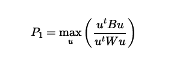

où :

- **B** est la matrice de dispersion inter‑groupes,
- **W** est la matrice de dispersion intra‑groupe,
- **u** est le vecteur discriminant recherché.

Elle conduit à résoudre l’équation généralisée :

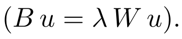

Les *solutions u* sont les **vecteurs propres** généralisés, et les valeurs *lambda* sont les **valeurs propres**, qui mesurent la capacité discriminante de chaque axe.

Pour trouver cesdits vecteurs et valeurs propres, nous utilisons la méthode de la **diagonalisation.**

### 2.1 Diagonalisation

Nous calculons la matrice du **ratio B/W:**

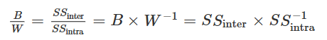

```r
# Diagonalisation
SS_total  <- res$SS_tot
SS_inter  <- res$SS_Inter
SS_intra  <- res$SS_Intra
B_W <- SS_inter %*% solve(SS_intra)

B_W %>% kbl(digits=3, caption = "Matrice du ratio B/W") %>%
  kable_styling(bootstrap_options = "striped", full_width = F, position = "center", latex_options = 'stripped') %>%
  scroll_box( height = "200px")
```

Matrice du ratio B/W

|  | TP | Soleil | Chaleur | Pluie |
| --- | --- | --- | --- | --- |
| TP | 1.781 | 1.371 | -4.721 | -1.176 |
| Soleil | 1.591 | 1.268 | -5.276 | -1.101 |
| Chaleur | 0.108 | 0.081 | -0.240 | -0.069 |
| Pluie | -0.849 | -0.695 | 3.245 | 0.608 |

### 2.2 Vecteurs propres

Nous calculons maintenant **les vecteurs directeurs u** des axes factoriels et leur coefficient.

```r
# Matrice des vecteurs propres
diag    <- eigen(B_W)
vecteurs_propres    <- Re(diag$vectors)
df_vecteurs_propres <- data.frame(vecteurs_propres)
colnames(df_vecteurs_propres) <- rownames(df_vecteurs_propres) <- axes

df_vecteurs_propres  %>% kbl(digits=3, caption = "Matrice des vecteurs propres U") %>%
  kable_styling(bootstrap_options = "striped", full_width = F, position = "center", latex_options = 'stripped') %>%
  scroll_box( height = "200px")
```

Matrice des vecteurs propres U

|  | Axe_1 | Axe_2 | Axe_3 | Axe_4 |
| --- | --- | --- | --- | --- |
| Axe_1 | -0.702 | -0.822 | -0.550 | 0.146 |
| Axe_2 | -0.627 | 0.229 | 0.834 | 0.478 |
| Axe_3 | -0.043 | -0.092 | 0.035 | -0.022 |
| Axe_4 | 0.335 | -0.513 | 0.000 | 0.866 |

La maximisation de P1 revient à diagonaliser la matrice *SSinter×SS−1intra.* Les vecteurs propres correspondent alors aux vecteurs directeurs des axes factoriels. Ces derniers devront être cependant **normalisés.**

Les valeurs propres correspondent à la part de dispersion expliquée par chaque axe. Seulement, la matrice du ratio B/W n’est pas symétrique ce qui conduit à des résultats non exploitables car non normées. Pour y parvenir, nous normalisons la matrice des vecteurs propres :

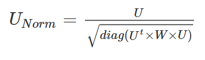

```r
# Matrice de normalisation
U   <- vecteurs_propres
W   <- SS_intra
U_norm <- diag(sqrt(diag(t(U) %*% W %*% U)))

U_norm  %>% kbl(digits=3, caption = "Matrice de normalisation") %>%
  kable_styling(bootstrap_options = "striped", full_width = F, position = "center", latex_options = 'stripped') %>%
  scroll_box( height = "200px")
```

Matrice de normalisation

| 514.758 | 0.000 | 0.000 | 0.000 |
| --- | --- | --- | --- |
| 0.000 | 458.924 | 0.000 | 0.000 |
| 0.000 | 0.000 | 398.689 | 0.000 |
| 0.000 | 0.000 | 0.000 | 438.576 |

```r
Un <- U %*% solve(U_norm)
df_Un <- data.frame(Un)
colnames(df_Un) <- axes

df_Un  %>% kbl(digits=6, caption = "Matrice des valeurs propres") %>%
  kable_styling(bootstrap_options = "striped", full_width = F, position = "center", latex_options = 'stripped') %>%
  scroll_box( height = "200px")
```

| Axe_1 | Axe_2 | Axe_3 | Axe_4 |
| --- | --- | --- | --- |
| -0.001364 | -0.001792 | -0.001380 | 0.000332 |
| -0.001218 | 0.000498 | 0.002092 | 0.001091 |
| -0.000083 | -0.000200 | 0.000087 | -0.000050 |
| 0.000650 | -0.001118 | 0.000000 | 0.001974 |

### 2.3 Valeurs propres

Comme pour les vecteurs propres, nous éliminons la partie imaginaire. les valeurs sont les suivantes:

```r
# Valeurs propres
valeurs_propres <- Re(diag$values)
df_valeurs_propres <- data.frame(VP = valeurs_propres) ; rownames(df_valeurs_propres) <- axes

df_valeurs_propres  %>% kbl(digits=6, caption = "Valeurs propres") %>%
  kable_styling(bootstrap_options = "striped", full_width = F, position = "center", latex_options = 'stripped') %>%
  scroll_box( height = "200px")
```

Valeurs propres

|  | VP |
| --- | --- |
| Axe_1 | 3.278860 |
| Axe_2 | 0.138574 |
| Axe_3 | 0.000000 |
| Axe_4 | 0.000000 |

Enfin, la part de dispersion expliquée par les axes (inertie des axes) est calculée par l’expression suivante:

```r
# Part de dispersion
Inertie <-  df_valeurs_propres / sum(df_valeurs_propres) * 100

Inertie  %>% kbl(digits=3, caption = "Part de dispersion") %>%
  kable_styling(bootstrap_options = "striped", full_width = F, position = "center", latex_options = 'stripped') %>%
  scroll_box( height = "200px")
```

Part de dispersion

|  | VP |
| --- | --- |
| Axe_1 | 95.945 |
| Axe_2 | 4.055 |
| Axe_3 | 0.000 |
| Axe_4 | 0.000 |

### 2.4 Coordonnées des individus

Seuls les deux premiers axes factoriels sont à prendre en compte puisqu’ils représentent à eux seul l’intégralité de la dispersion et donc de “l’information contenu dans le tableau initial Z”.

Nous créons un data.frame *Scores_df* qui inclue les coordonnées des individus sur les deux premiers axes factoriels ainsi que les différentes classes auxquelles ils appartiennent (variable ‘Class’). On prendra soin de bien vérifier que l’entête de la variable (nom de la variable) soit égale à ‘Class’

```r
AFD_graph1 <- function(Scores, label = T, center = F)
{
  colnames(Scores)[3] <- 'Class'

  gr <- ggplot()
  if (label == F)
  {
    gr <- gr + geom_point(data = Scores  ,aes(x = Axe_1, y = Axe_2), colour = '#0066CC', size = 1)
  }else
  {
    gr <- gr + geom_point(data = Scores  ,aes(x = Axe_1, y = Axe_2, colour = Class), size = 2)
  }

  if(center == T)
  {
    df_center <- aggregate(Scores[,-3], by = list(Scores$Class ), mean)
    gr <- gr + geom_point(data = df_center, aes(x = Axe_1, y = Axe_2, colour = Group.1 ), shape = 23, size = 4)

  }
  gr <- gr + geom_hline(yintercept = 0 , size = 0.1, colour = 'red') +
    geom_vline(xintercept = 0 , size = 0.1, colour = 'red')
  return(gr)
}
```

Enfin, nous effectuons un **test de Wilks.** En analyse factorielle discriminante, il s’agit de tester successivement le caractère discriminant des axes vis à vis des différentes classes.

```r
# Interférence statistique
eta_2 = sqrt(valeurs_propres[1:2] / (1 + valeurs_propres[1:2]))
eta_2  %>% kbl(digits=3, caption = "Corrélation canonique") %>%
  kable_styling(bootstrap_options = "striped", full_width = F, position = "center", latex_options = 'stripped') # %>%
```

Corrélation canonique

| x |
| --- |
| 0.875 |
| 0.349 |

```r
axe_selected <- 2
result     <- matrix(0, nrow = 2, ncol = 6)
result[,1] <- valeurs_propres[1:axe_selected]
result[,2] <- valeurs_propres[1:axe_selected]/sum(valeurs_propres) *100
result[,3] <- sqrt(valeurs_propres[1:axe_selected]/(1+valeurs_propres[1:axe_selected]))
result[,4] <- cumprod(1 - result[,3]^2)
result[,5] <- -(N - (p + k)/2 - 1) * log(result[,4])
result[,6] <-  1- pchisq(result[,5],p * (k-1) )


result <- data.frame(result)

colnames(result) <- c('valeur propres',' % inertie','correlation',' Wilks',' Kh Deux','p.value')
result  %>% kbl(digits=3, caption = "Résultat de AFD") %>%
  kable_styling(bootstrap_options = "striped", full_width = F, position = "center", latex_options = 'stripped') #%>%
```

Résultat de AFD

| valeur propres | % inertie | correlation | Wilks | Kh Deux | p.value |
| --- | --- | --- | --- | --- | --- |
| 3.279 | 95.945 | 0.875 | 0.234 | 42.884 | 0 |
| 0.139 | 4.055 | 0.349 | 0.205 | 46.712 | 0 |

## 3 Encapsulation

Nous créons maintenant une fonction générique que nous nommons AFD. Elle se définit sous la forme :

*AFD <- function(X,Y,SS_tot, SS_intra, SS_inter, nb_axes = 2)*

avec :

- **X et Y :** respectivement, les variables prédictives et la variable à prédire.
- **SS_tot, SS_intra, SS_inter :** les sommes des carrés calculées à partir de la fonction MANOVA.
- **nb_axes :** le nombre d’axes sélectionné pour réaliser les projections.

Cette fonction retourne une liste dont les éléments sont les vecteurs propres normalisés, les valeur propres, les scores et le tableau des résultats du test de Wilks.

Le data frame des Scores calculés à partir da la fonction AFD corresppondent à l’argument de la fonction *AFD_graph1.*

```r
# Encapsulation du code
AFD <- function(X,Y,SS_tot, SS_intra, SS_inter, nb_axes = 2)
{
  N   <- nrow(X)
  k   <- length(unique(Y))
  p   <- ncol(X)
  axes <- paste0('Axe_', 1: ncol(X))
  # Matrice B/W
  B_W <- SS_inter %*% solve(SS_intra)
  # Diagonalisation
  diag    <- eigen(B_W)
  # Matrice vecteurs propres
  vecteurs_propres    <- Re(diag$vectors)
  df_vecteurs_propres <- data.frame(vecteurs_propres)
  colnames(df_vecteurs_propres) <- rownames(df_vecteurs_propres) <- axes
  # Normalisation
  U   <- vecteurs_propres
  W   <- SS_intra
  U_norm <- diag(sqrt(diag(t(U) %*% W %*% U)))
  Un  <- U %*% solve(U_norm)
  df_Un <- data.frame(Un) ; colnames(df_Un) <- axes
  # Valeurs propres
  valeurs_propres <- Re(diag$values)
  df_valeurs_propres <- data.frame(VP = valeurs_propres) ; rownames(df_valeurs_propres) <- axes
  # Inertie
  Inertie <-  df_valeurs_propres / sum(df_valeurs_propres) * 100
  # Coordonnées des individus
  Z <- scale(X,center = T, scale = F)
  Scores <- data.frame(Z %*% Un) ; names(Scores) <-  axes
  Scores <- Scores[,1:nb_axes]
  Scores_df <- data.frame(cbind(Scores, Class = Y))

  result     <- matrix(0, nrow = nb_axes, ncol = 6)
  result[,1] <- valeurs_propres[1:nb_axes]
  result[,2] <- valeurs_propres[1:nb_axes]/sum(valeurs_propres) *100
  result[,3] <- sqrt(valeurs_propres[1:nb_axes]/(1+valeurs_propres[1:nb_axes]))
  # Corrélation canonique
  result[,4] <- cumprod(1 - result[,3]^2)
  result[,5] <- -(N - (p + k)/2 - 1) * log(result[,4])
  result[,6] <-  1- pchisq(result[,5],p * (k-1) )


  result <- data.frame(result)

  colnames(result) <- c('valeur propres',' % inertie','correlation',' Wilks',' Kh Deux','p.value')

  return(list( Unorm = df_Un,
               Val_P = valeurs_propres ,
               Scores = Scores_df,
               Result = result
  ))

} # Modèle AFD
```

## 4 Application

Pour la validation, on utilise le fichier iris fourni par défaut en R.

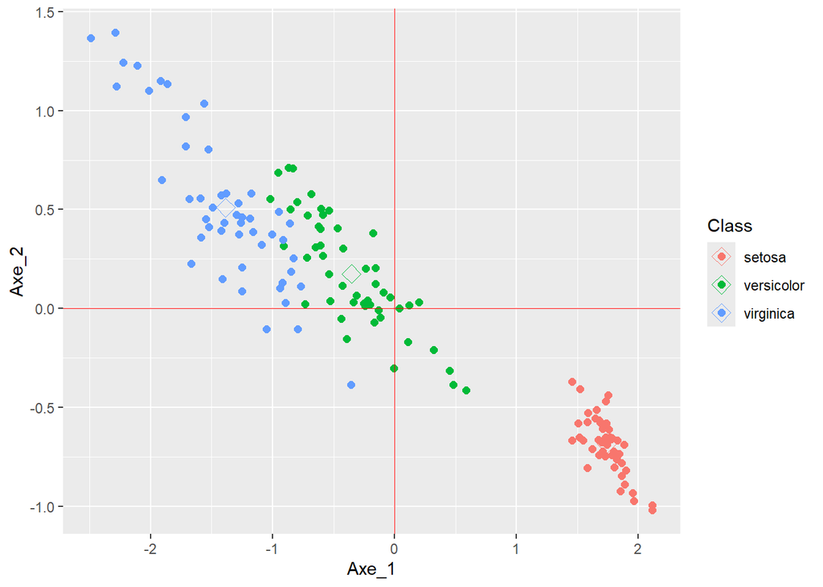

```r
## Application directe : iris
df_iris <- iris
X_iris <- df_iris[,-5]
Y_iris <- df_iris[5]
res_iris <- MANOVA(X_iris,Y_iris)
afd_iris <- AFD(X_iris,Y_iris, res_iris$SS_tot, res_iris$SS_Intra, res_iris$SS_Inter)
gr_iris  <- AFD_graph1(afd_iris$Scores, center = T)
print(gr_iris)
```

```r
afd_iris$Unorm %>% kbl(digits=3, caption = "Matrice de valeurs propres") %>%
  kable_styling(bootstrap_options = "striped", full_width = F, position = "center", latex_options = 'stripped') %>%  scroll_box( height = "200px")
```

| Axe_1 | Axe_2 | Axe_3 | Axe_4 |
| --- | --- | --- | --- |
| -0.229 | 0.510 | -0.345 | -0.164 |
| 0.061 | -0.197 | -0.074 | -0.245 |
| -0.565 | 0.237 | 0.068 | -0.032 |
| -0.239 | -0.376 | -0.063 | -0.010 |

```r
afd_iris$Val_P %>% kbl(digits=3, caption = "Valeurs propres") %>%
  kable_styling(bootstrap_options = "striped", full_width = F, position = "center", latex_options = 'stripped') %>%  scroll_box( height = "200px")
```

Valeurs propres

| x |
| --- |
| 391.683 |
| 13.465 |
| 3.362 |
| 2.123 |

```r
afd_iris$Scores %>% kbl(digits=3, caption = "Corrélation canonique") %>%
  kable_styling(bootstrap_options = "striped", full_width = F, position = "center", latex_options = 'stripped') %>%  scroll_box( height = "200px")
```

| Axe_1 | Axe_2 | Species |
| --- | --- | --- |
| 1.768 | -0.649 | setosa |
| 1.783 | -0.652 | setosa |
| 1.897 | -0.817 | setosa |
| 1.801 | -0.801 | setosa |
| 1.797 | -0.720 | setosa |
| 1.506 | -0.579 | setosa |
| 1.852 | -0.922 | setosa |
| 1.728 | -0.657 | setosa |
| 1.891 | -0.888 | setosa |
| 1.756 | -0.611 | setosa |
| 1.655 | -0.512 | setosa |
| 1.717 | -0.735 | setosa |
| 1.829 | -0.666 | setosa |
| 2.113 | -0.992 | setosa |
| 1.751 | -0.438 | setosa |
| 1.581 | -0.572 | setosa |
| 1.732 | -0.674 | setosa |
| 1.744 | -0.686 | setosa |
| 1.456 | -0.369 | setosa |
| 1.706 | -0.722 | setosa |
| 1.523 | -0.405 | setosa |
| 1.676 | -0.740 | setosa |
| 2.114 | -1.018 | setosa |
| 1.514 | -0.651 | setosa |
| 1.548 | -0.664 | setosa |
| 1.647 | -0.554 | setosa |
| 1.624 | -0.708 | setosa |
| 1.688 | -0.574 | setosa |
| 1.739 | -0.578 | setosa |
| 1.728 | -0.746 | setosa |

[output cut: 120 more lines]

```r
afd_iris$Result  %>% kbl(digits=3, caption = "Résultat de AFD") %>%
  kable_styling(bootstrap_options = "striped", full_width = F, position = "center", latex_options = 'stripped') %>%  scroll_box( height = "200px")
```

Résultat de AFD

| valeur propres | % inertie | correlation | Wilks | Kh Deux | p.value |
| --- | --- | --- | --- | --- | --- |
| 391.683 | 95.385 | 0.999 | 0.003 | 875.045 | 0 |
| 13.465 | 3.279 | 0.965 | 0.000 | 1266.451 | 0 |